# Restoration of the September 2025 EBS Pollock ADMB–RTMB Bridge

Provenance and numerical verification

Author

EBS Pollock assessment development

Published

August 3, 2026

# 1 Executive result

The September 2025 fixed-parameter bridge has been restored from the archived NOAA-AFSC source and independently reproduced using the bundled `for_rtmb` ADMB artifacts. The automated regression gate passed during this render.

Table 1: Numerical bridge results recalculated during this Quarto render.

| metric | value |
| --- | --- |
| ADMB total NLL | 7940.720000000 |
| RTMB total NLL | 7940.715902252 |
| Absolute total NLL difference | 0.004097748 |
| Maximum key percent difference | 0.000492728% |
| Maximum absolute gradient | 6.365350e-06 |

The absolute total NLL difference is 0.004097748, the maximum key output difference is 0.000492728%, and the maximum absolute gradient is 6.36535e-06.

# 2 Reference configuration

The numerical reference uses the following paired implementations:

- ADMB template: `admb/runs/for_rtmb/pm.tpl`.
- ADMB estimates and report: `pm.par`, `pm.rep`, and `pm.std` in the same directory.
- RTMB objective: the restored `R/Rpm.R` and its historical helper functions.
- Parameter mapping: the historical report-era `R/config.R`.

The report-era `runs/rtmb/pm.tpl` and the current bundled `admb/runs/for_rtmb/pm.tpl` share SHA-256 digest `d1384a696de864c0918542dcb5992272ba3283b617f00ad8efc7b3e2a391d66b`. The restored historical `Rpm.R` has digest `b3f360b324cc57af8248d97dea12e9f6cf94e5e07fae5494401a369e4de775cb`.

The full manifest is in `bridge/sept_2025.sha256`. The historical sources and published report are linked in `BRIDGE_PROVENANCE.md`.

# 3 Accuracy of the restored bridge

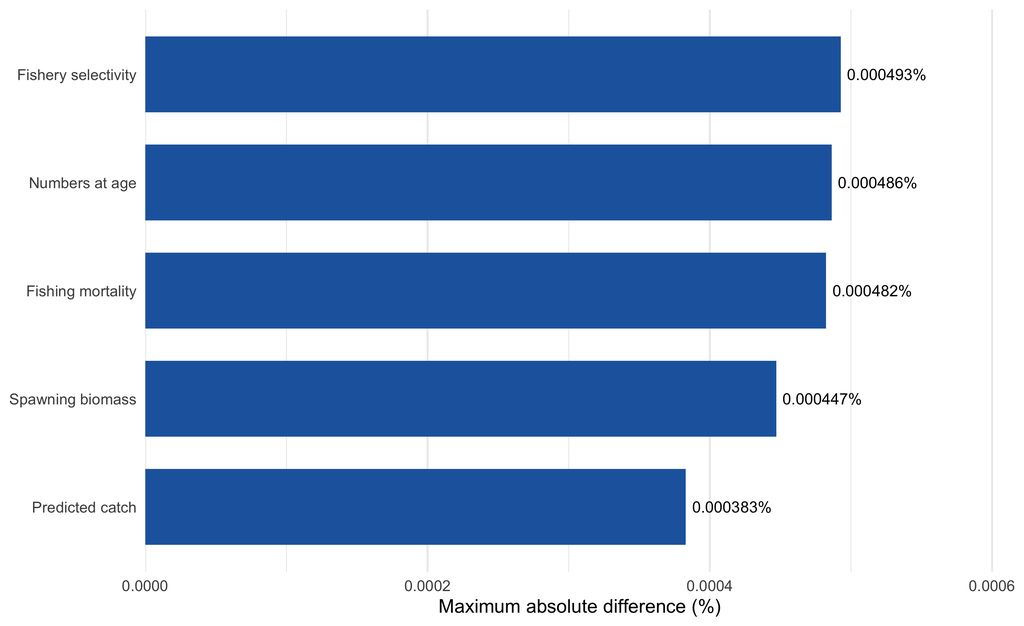

Figure 1: Maximum absolute percentage differences between restored RTMB outputs and the ADMB bridge report. Select the figure to open the lightbox.

All key state variables, predictions, and selectivity outputs differ by less than `0.0005%`. These are rounding-scale differences from transferring ADMB outputs through text files rather than substantive model discrepancies.

# 4 Required development sequence

1. Retain this report and `tests/test_sept_2025_bridge.R` as the deterministic gate.
2. Reintroduce selectable fishery forms without changing form 0; rerun the gate.
3. Add double-logistic and 2D-AR1 sensitivities one at a time; rerun the gate after each.
4. Reintroduce profiling helpers and rerun the deterministic gate.
5. Reintroduce SparseNUTS only after its underlying deterministic model passes.
6. Implement Grant Adams’ `m23_rceattle_full` as a separately named RTMB configuration with independent artifacts and bridge thresholds.

# 5 Reproducibility

```r
cat(paste(bridge_output, collapse = "\n"))
```

```
outer mgc:  6.36535e-06
ADMB total NLL: 7940.720000000
RTMB total NLL: 7940.715902252
Absolute total NLL difference: 0.004097748
Maximum key percent difference: 0.000492728%
Maximum absolute gradient: 6.3653498e-06
PASS: September 2025 ADMB-to-RTMB bridge reproduced.
```

The bridge can be checked independently of this document with:

```bash
Rscript tests/test_sept_2025_bridge.R
```

Verify the archived source and ADMB artifact checksums with:

```bash
shasum -a 256 -c bridge/sept_2025.sha256
```

The active RTMB profiling work remains isolated on `agent/rtmbprof-stage1`. This restored report was developed on `bridge/restore-sept-2025` so the dirty profiling worktree was not modified.